# GEOG 6000 Lab 08b Visualizing spatial Data in R

Simon Brewer and Blake Vernon

21 October, 2026

The following files will be used in this lab, all available on Canvas:

- Climate dataset for Western North America: *WNAclimate.csv*
- New York state polygon data in a shapefile: *NY_Data.zip*
- A NetCDF file of global monthly air temperature: *air.mon.ltm.nc*

You will need to download these files from Canvas, and move them from your `Downloads` folder to the `datafiles` folder that you made previously. Make sure to unzip the zip files so that R can access the content. Note that on Windows, you will need to right-click on the file and select ‘Extract files’.

You will also need to make sure the following packages are installed on your computer:

```r
pkgs <- c("mapview",
          "terra",
          "RColorBrewer"
          "sf",
          "tmap",
          "viridis")

install.packages(pkgs)
```

```r
library(mapview)
library(terra)
library(RColorBrewer)
library(sf)
library(tmap)
library(viridis)
```

# Static Maps with `tmap`

[`tmap`](https://mtennekes.github.io/tmap/) is built on top of `ggplot2` and works in a similar way by building a series of layers with map geometries and elements. We start by using `tm_shape()` to identify the spatial object to be used, and then geometries are added, including filled polygons, borders, legends, etc.

## Polygon data

We’ll start by making some maps based on the NY shapefile. Start by loading this, then extract only the polygons belonging to Syracuse.

```r
NY8 <- st_read("./data/NY_data/NY8_utm18.shp")
Syracuse <- NY8[NY8$AREANAME == "Syracuse city", ]
```

First, let’s make a simple map showing the polygon outlines using `tm_borders()`:

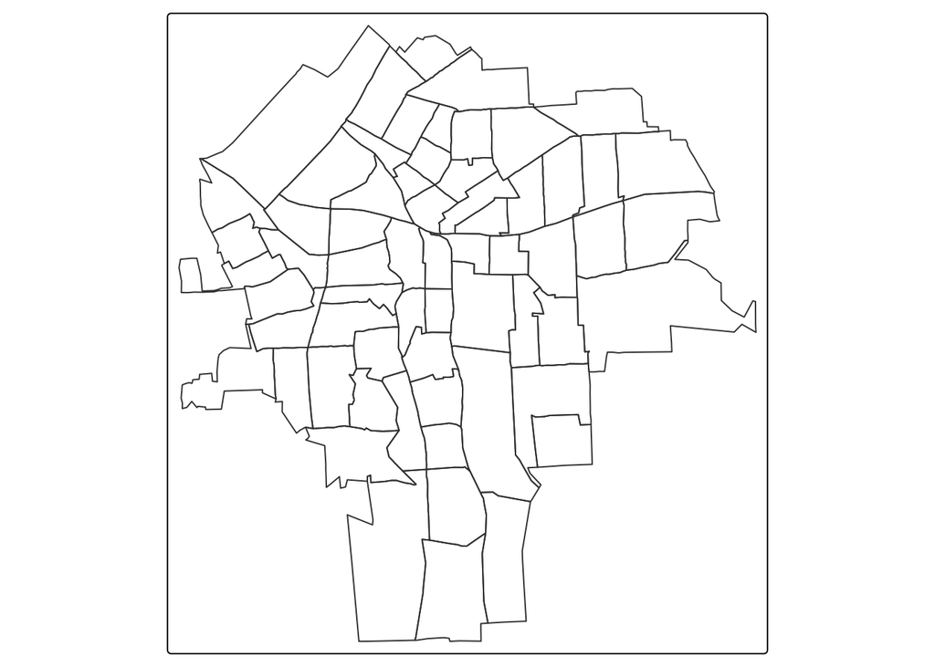

```r
tm_shape(Syracuse) + tm_borders()
```

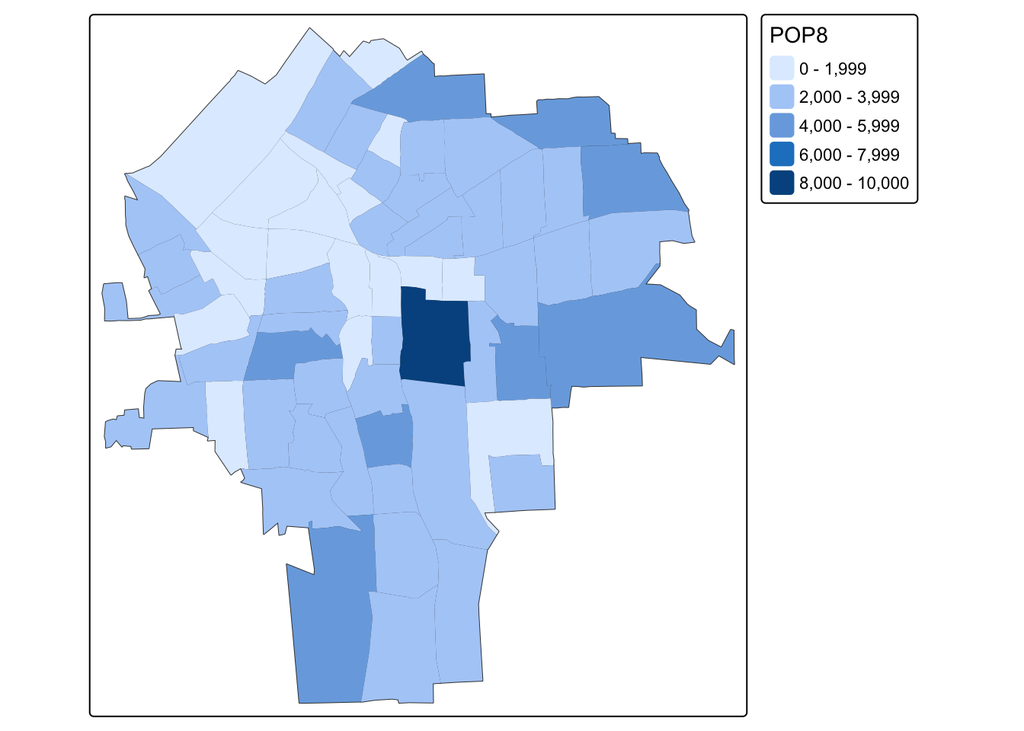

```r
tm_shape(Syracuse) +
  tm_borders() +
  tm_fill("POP8")
```

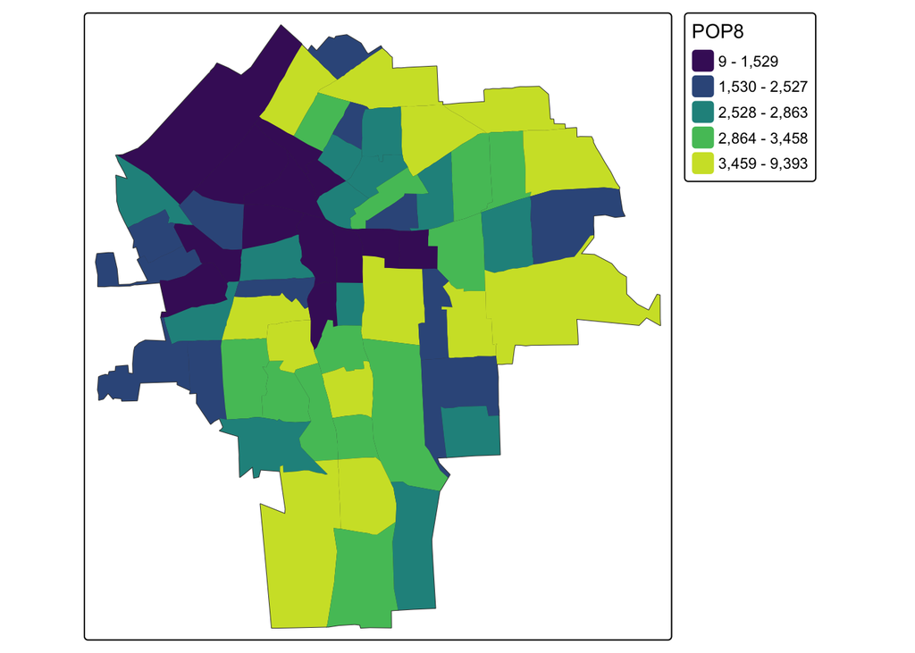

```r
tm_shape(Syracuse) +
  tm_borders() +
  tm_fill("POP8", tm_scale_intervals(values = "viridis", style = "quantile"))
```

Other map elements can be added. Here we add a longitude/latitude graticule with `tm_graticules()`, a north arrow with `tm_compass()`, and a line of text showing the date the map was made with `tm_credits()`. We’ll also switch to one of the ColorBrewer palettes (the `-` reverses the order of colors):

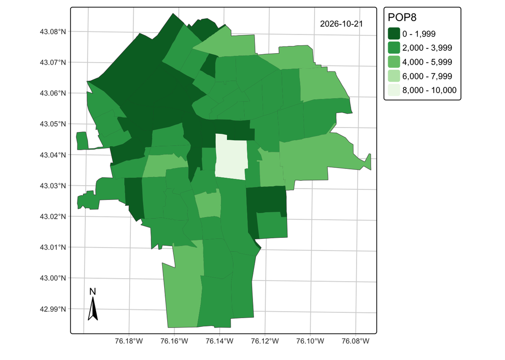

```r
tm_shape(Syracuse) +
  tm_graticules(col = "lightgray") +
  tm_borders() +
  tm_fill("POP8", tm_scale_intervals(values = "-brewer.greens", style = "pretty")) +
  tm_compass(position = c("left", "bottom")) +
  tm_credits("2026-10-21", position = c("right", "top"))
```

Although we will mainly use **tmap** for static plots in this class, you can make most maps produced by **tmap** interactive by setting the ‘mode’ of tmap. The command `tmap_mode('plot')` (the default) make static maps, and `tmap_mode('view')` makes these interactive:

```r
## Setting as interactive
tmap_mode('view')
tm_shape(Syracuse) +
  tm_borders() +
  tm_fill("POP8", tm_scale_intervals(values = "-brewer.greens", style = "pretty"),
          fill_alpha = 0.5)
```

[interactive chart not shown]

```r
## Setting back to static
tmap_mode('plot')
```

## Point data

We’ll next make some maps with the Western North American site data. As before, we load the data, then convert to an `sf` object.

```r
wna_climate <- read.csv("./data/WNAclimate.csv")

wna_climate <- st_as_sf(wna_climate,
                        coords = c("LONDD", "LATDD"),
                        crs = 4326)
```

Next, we’ll download country outlines and river centerlines from [Natural Earth](https://www.naturalearthdata.com) using the **rnaturalearth** package (you will need to install this). This will download layers from the Natural Earth website - there are a variety of these available, including country and state boundaries, physical features (rivers, lakes, etc) and cultural features (place names, roads, etc). There are three levels of resolution: 1:10m, 1:50m and 1:110m. To download a layer, you need to specify the resolution (`scale`) and the name of the layer. The full set of available layers can be found at their website:

```r
library(rnaturalearth)

countries50 <- ne_download(scale = 50, type = "admin_0_countries")
rivers50 <- ne_download(scale = 50, type = "rivers_lake_centerlines", category = "physical")
```

Individual symbols can be plotted on a color scale using `tm_symbols`.

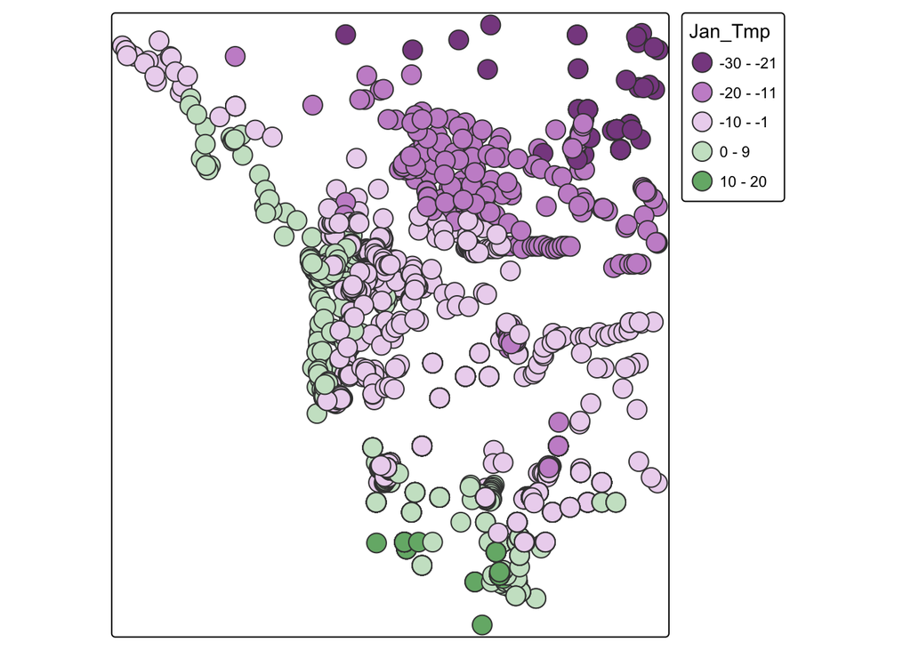

```r
tm_shape(wna_climate) +
  tm_symbols(fill = "Jan_Tmp")
```

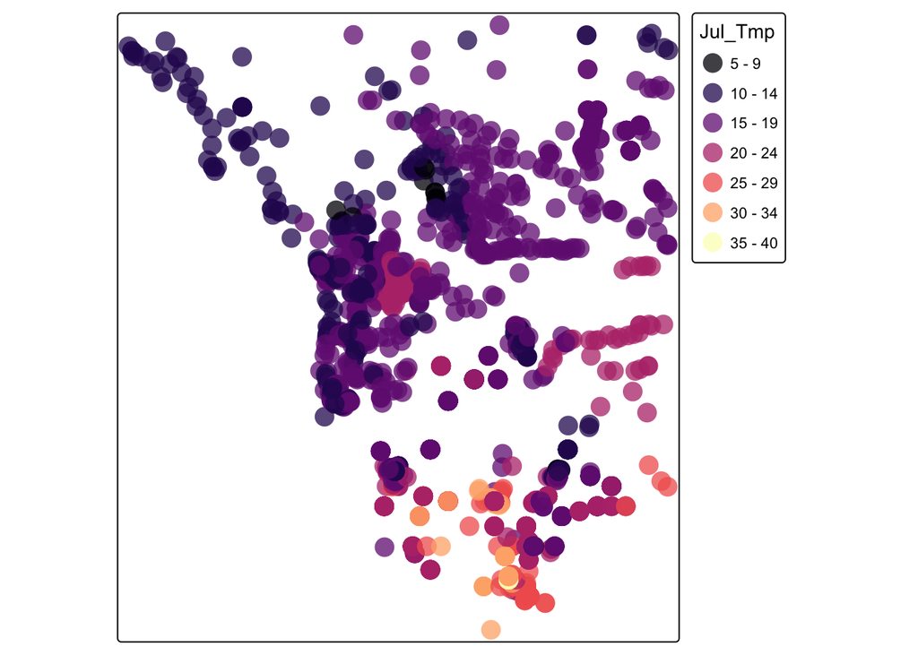

```r
tm_shape(wna_climate) +
  tm_symbols(fill = "Jul_Tmp",
             fill.scale = tm_scale_intervals(values = "magma", style = "pretty", n = 10),
             fill_alpha = 0.75,
             col = NULL)
```

We’ll next add country boundaries from the Natural Earth shapefile loaded earlier. Note that as this is a different spatial object, we have to use `tm_shape()` a second time to reference this, then use `tm_borders()` to add the lines.

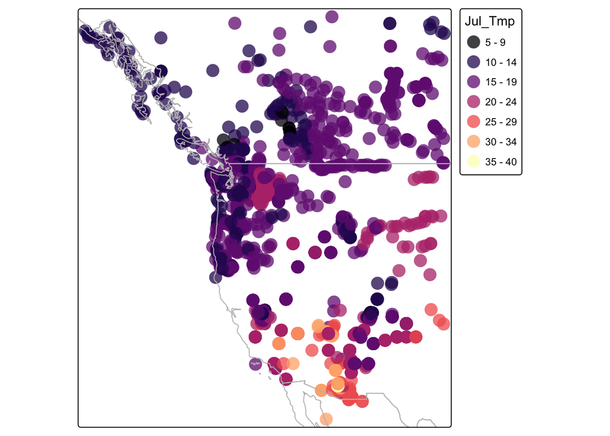

```r
tm_shape(wna_climate) +
  tm_symbols(fill = "Jul_Tmp",
             fill.scale = tm_scale_intervals(values = "magma", style = "pretty", n = 10),
             fill_alpha = 0.75,
             col = NULL) +
  tm_shape(countries50) +
  tm_borders(col = "gray")
```

Note that here we’ve plotted the symbols first to set the plotting window. Unfortunately, this means that the country lines are added on top of the symbols. If we add the country outlines first, then the window is set to the globe.

```r
tm_shape(countries50) +
  tm_borders(col = "gray") +
  tm_shape(wna_climate) +
  tm_symbols(fill = "Jul_Tmp",
             fill.scale = tm_scale_intervals(values = "magma", style = "pretty", n = 10),
             fill_alpha = 0.75,
             col = NULL)
```

[output not shown]

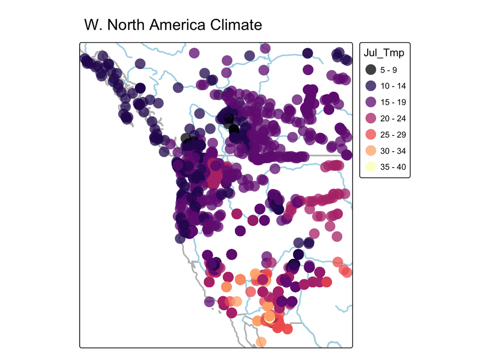

```r
tm_shape(countries50, bbox = st_bbox(wna_climate)) +
  tm_borders(col = "gray", lwd = 2) +
  tm_shape(rivers50) +
  tm_lines(col = 'lightblue', lwd = 2) +
  tm_shape(wna_climate) +
  tm_symbols(fill = "Jul_Tmp",
             fill.scale = tm_scale_intervals(values = "magma", style = "pretty", n = 10),
             fill_alpha = 0.75,
             col = NULL) +
  tm_title("W. North America Climate")
```

We can also use one of **tmap**’s preset themes with `tm_style()`:

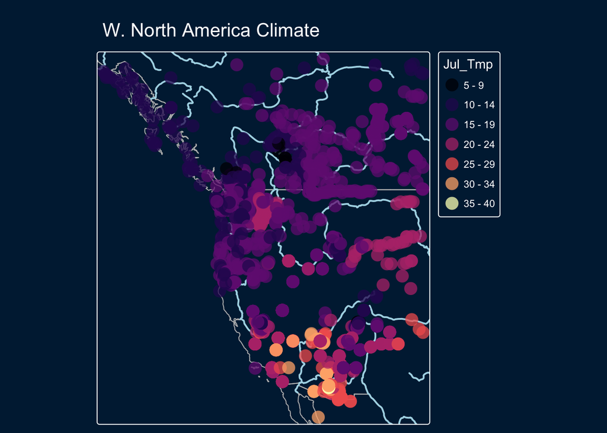

```r
tm_shape(countries50, bbox = st_bbox(wna_climate)) +
  tm_borders(col = "gray") +
  tm_shape(rivers50) +
  tm_lines(col = 'lightblue', lwd = 2) +
  tm_shape(wna_climate) +
  tm_symbols(fill = "Jul_Tmp",
             fill.scale = tm_scale_intervals(values = "magma", style = "pretty", n = 10),
             fill_alpha = 0.75,
             col = NULL) +
  tm_title("W. North America Climate") +
  tm_style("cobalt")
```

Finally, we can write this map to a file using `tmap_save()`. To do this, assign the output of all the **tmap** functions to an R object. Then specify this object and a file name. I’ve used pdf output here, but you can also use `png`, `tif` or most other common format extensions.

```r
map1 <- tm_shape(countries, bbox = st_bbox(wna_climate)) +
  tm_style("cobalt") +
  tm_borders(col = "gray") +
  tm_shape(rivers50) +
  tm_lines(col = 'lightblue', lwd = 2) +
  tm_shape(wna_climate) +
  tm_symbols(fill = "Jul_Tmp",
             fill.scale = tm_scale_intervals(values = "magma", style = "pretty", n = 10),
             fill_alpha = 0.75,
             col = NULL) +
  tm_title("W. North America Climate")

tmap_save(map1, "wna_jan_tmp.pdf")
```

## Faceted maps

**tmap** includes a similar faceting function to **ggplot2**. This allows you to make several different versions of the same map split by some grouping factor. A good example of this is where you have repeated measures over time for a set of locations, and you would like to display each time periods separately. You can make all the individual maps, and then add them together with `tmap_arrange()`, or use `tm_facets()`. To illustrate this, we’ll load a built in dataset (`metro`) that has population sizes for major metropolitan centers

```r
data(metro)
head(metro)
```

```
## Simple feature collection with 6 features and 12 fields
## Geometry type: POINT
## Dimension:     XY
## Bounding box:  xmin: -64.18105 ymin: -34.60508 xmax: 69.17246 ymax: 36.7525
## Geodetic CRS:  WGS 84
##            name             name_long iso_a3 pop1950 pop1960 pop1970 pop1980
## 2         Kabul                 Kabul    AFG  170784  285352  471891  977824
## 8       Algiers El Djazair  (Algiers)    DZA  516450  871636 1281127 1621442
## 13       Luanda                Luanda    AGO  138413  219427  459225  771349
## 16 Buenos Aires          Buenos Aires    ARG 5097612 6597634 8104621 9422362
## 17      Cordoba               Cordoba    ARG  429249  605309  809794 1009521
## 25      Rosario               Rosario    ARG  554483  671349  816230  953491
##     pop1990  pop2000  pop2010  pop2020  pop2030                    geometry
## 2   1549320  2401109  3722320  5721697  8279607   POINT (69.17246 34.52889)
## 8   1797068  2140577  2432023  2835218  3404575     POINT (3.04197 36.7525)
## 13  1390240  2591388  4508434  6836849 10428756   POINT (13.23432 -8.83682)
## 16 10513284 12406780 14245871 15894307 16956491 POINT (-58.40037 -34.60508)
## 17  1200168  1347561  1459268  1562509  1718192  POINT (-64.18105 -31.4135)
## 25  1083819  1152387  1298073  1453814  1606993 POINT (-60.63932 -32.94682)
```

This is an `sf` object, with a set of columns with population size for each decade between 1950 and 2030. To plot this as a facetted map, we first need to convert this to long format with one column for area, one for population size and one for year. We’ll do this imply by concatenating the different populations sizes, and repeating the location names and year, then put it all into a temporary data frame:

```r
pop <- c(metro$pop1950, metro$pop1960, metro$pop1970,
         metro$pop1980, metro$pop1990, metro$pop2000)

name <- rep(metro$name, 6)
year <- rep(seq(1950, 2000, by = 10), each = nrow(metro))

tmp <- data.frame(pop, name, year)
```

Now we’ll merge this with the original `sf` object using the location names:

```r
metro_long <- merge(metro, tmp, by = "name")
```

Now we can go ahead and plot this. We’ll use symbol size to represent the population size and facet by year:

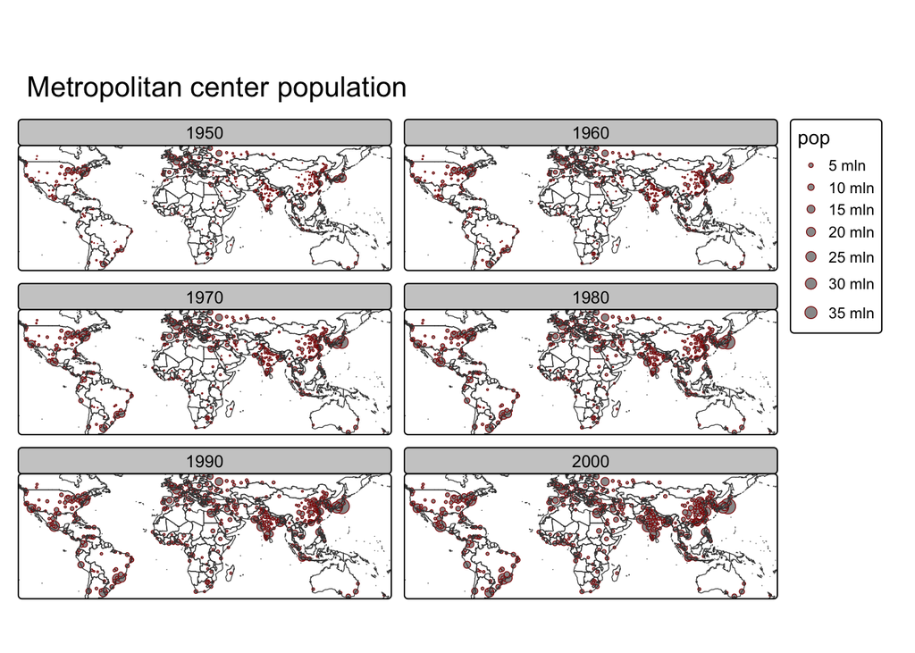

```r
tm_shape(metro_long) +
  tm_facets(by = "year") +
  tm_symbols("pop", col = "darkred") +
  tm_shape(countries50) +
  tm_borders() +
  tm_title("Metropolitan center population")
```

## Raster data

In the final example, we’ll make figures using a dataset of global air temperatures in NetCDF format Start by reading the data (we also change the name of the layer, to reduce the amount of typing later on…) and setting the CRS to WGS84

```r
air_temp <- rotate(rast("./data/air.mon.ltm.nc")[[1]])

air_temp
```

```
## class       : SpatRaster
## size        : 73, 144, 1  (nrow, ncol, nlyr)
## resolution  : 2.5, 2.5  (x, y)
## extent      : -181.25, 178.75, -91.25, 91.25  (xmin, xmax, ymin, ymax)
## coord. ref. :
## source(s)   : memory
## varname     : air (Monthly Long Term Mean Air Temperature at sigma level 0.995)
## name        :      air_1
## min value   : -37.775051
## max value   :  33.589531
## time (days) : 0000-12-30
```

```r
names(air_temp) <- "jan_tmp"

crs(air_temp) <- "epsg:4326"
```

Now let’s make a plot using `tm_raster()`, which again takes similar options for color palettes. We’ll also add the country borders.

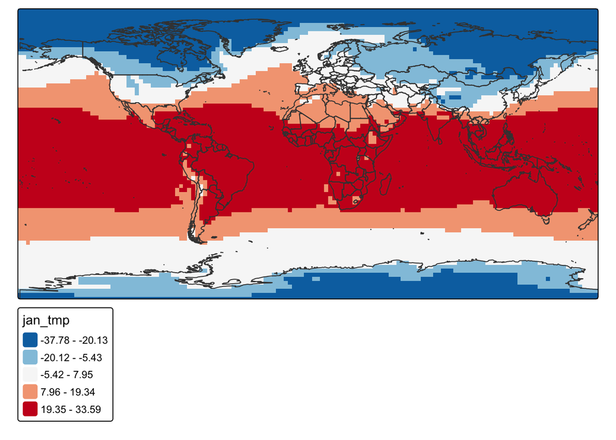

```r
tm_shape(air_temp) +
  tm_raster("jan_tmp", tm_scale_intervals(style = "fisher", values = "-brewer.rd_bu")) +
  tm_shape(countries50) +
  tm_borders()
```

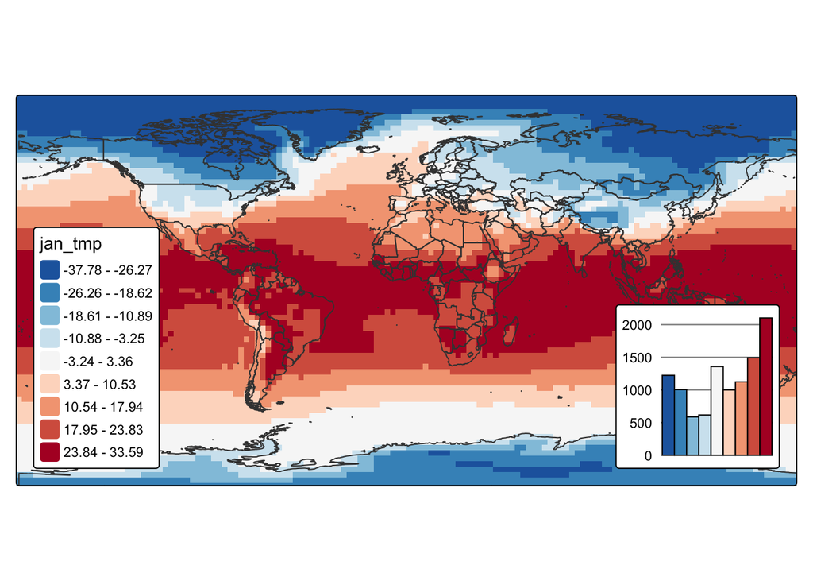

```r
tm_shape(air_temp) +
  tm_raster("jan_tmp",
            tm_scale_intervals(style = "fisher", values = "-brewer.rd_bu", n=9),
            col.chart = tm_chart_histogram(position = c("right", "bottom")) ,
            col.legend = tm_legend(position = c("left", "bottom"))) +
  tm_shape(countries50) +
  tm_borders()
```

## Tips and Tricks

For helpful tips and tricks, try:

```r
tmap_tip()
```

# Interactive maps with `mapview`

The [`mapview`](https://r-spatial.github.io/mapview/index.html) package provides functions to produce interactive maps in R by building on the R [`leaflet`](https://rstudio.github.io/leaflet/) package, which provides a low-level interface to the [javascript library](https://leafletjs.com/) of the same name. `mapview` supports multiple spatial data types, including points, lines, polygons, and rasters.

```r
mapview(wna_climate,
        col.regions = "darkred", # fill color
        color = "gray",          # outline color
        alpha.regions = 0.2,     # fill transparency
        alpha = 0.3)             # outline transparency
```

[interactive chart not shown]

The default basemap called when using `mapview()` is *CartoDB.positron*. Unfortunately this requires an API key to access it, so we can instead use other third-party map tiles. We’ll reset the default here to OpenStreetMap:

```r
mapviewOptions(basemaps = c("OpenStreetMap"))

mapview(Syracuse,
        col.regions = "darkgreen",
        color = "black")
```

[interactive chart not shown]

We can also set multiple basemaps that can then be changed interactively (you’ll need to click on the layer menu in the interactive plot to see a difference).

```r
mapviewOptions(basemaps = c("OpenStreetMap", "Esri.WorldGrayCanvas", "Esri.WorldImagery"))

mapview(Syracuse,
        col.regions = "darkgreen",
        color = "black")
```

[interactive chart not shown]

This also works with raster layers. Here we’ll load a Geotiff of NDVI values over Mount Kilimanjaro using **terra**:

```r
fn <- system.file("extdata", "kiliNDVI.tif", package = "mapview")

kilimanjaro_NDVI <- terra::rast(fn)[[1]]

mapview(kilimanjaro_NDVI,
        col.regions = viridis::viridis(n = 10)) # supply custom color palette
```

[interactive chart not shown]

Here we will only review a few of the many features that `mapview` provides.

## Basemaps

We can set also set basemaps manually by using the `map.types` argument in `mapview()`. For a list of possible basemap services, see [here](https://leaflet-extras.github.io/leaflet-providers/preview/). For convenience, the `leaflet` package also provides a named vector of these tile services supported by the leaflet plugin. The vector is called `providers` and you can access elements of the vector like you would any other:

```r
leaflet::providers[[35]]
```

```
## [1] "Thunderforest"
```

```r
leaflet::providers$Esri.WorldPhysical
```

```
## [1] "Esri.WorldPhysical"
```

```r
mapview(Syracuse,
        col.regions = "darkgreen",
        color = "black",
        map.types = c("Stadia.StamenWatercolor", "Stadia.StamenTonerLite"))
```

[interactive chart not shown]

## Layers

`mapview` provides for layering much in the same way that `ggplot2` does.

```r
Syracuse_centers <- st_centroid(Syracuse)

lyr1 <- mapview(Syracuse,
                col.regions = "darkgreen",
                color = "black")

lyr2 <- mapview(Syracuse_centers,
                col.regions = "darkblue",
                cex = 3) # size of point

lyr1 + lyr2
```

[interactive chart not shown]

## Aesthetic Mapping

We can also map attributes of the spatial data to various aesthetics.

```r
mapview(Syracuse,
        zcol = "POP8",
        col.regions = viridis::cividis(n = 10),
        alpha.regions = 0.85)
```

[interactive chart not shown]

```r
# breweries in Franconia, Germany
franconia_breweries <- mapview::breweries

# set point size to number of different types of beer served at each brewery
mapview(franconia_breweries, cex = "number.of.types")
```

[interactive chart not shown]

## Inset Map

For whatever reason, `mapview` does not currently support interactive inset maps. However, these can still be added using `leaflet` and a little tinkering with the mapview object.

```r
add_miniMap <- function(x) leaflet::addMiniMap(x@map)

imap <- mapview(franconia_breweries, cex = "number.of.types")

add_miniMap(imap)
```

[interactive chart not shown]